# Cyclistic Case Study (July 2023-July 2024)

Andrew McGough

2024-09-05

# INTRODUCTION - ABOUT THE COMPANY:

In 2016, Cyclistic launched a successful bike-share offering. Since then, the program has grown to a fleet of 5,824 bicycles that are geotracked and locked into a network of 692 stations across Chicago. The bikes can be unlocked from one station and returned to any other station in the system anytime.

Until now, Cyclistic’s marketing strategy relied on building general awareness and appealing to broad consumer segments. One approach that helped make these things possible was the flexibility of its pricing plans: single-ride passes, full-day passes, and annual memberships. Customers who purchase single-ride or full-day passes are referred to as casual riders. Customers who purchase annual memberships are Cyclistic members.

Cyclistic’s finance analysts have concluded that annual members are much more profitable than casual riders. Although the pricing flexibility helps Cyclistic attract more customers, Moreno believes that maximizing the number of annual members will be key to future growth. Rather than creating a marketing campaign that targets all-new customers, Moreno believes there is a solid opportunity to convert casual riders into members. She notes that casual riders are already aware of the Cyclistic program and have chosen Cyclistic for their mobility needs.

Moreno has set a clear goal: Design marketing strategies aimed at converting casual riders into annual members. In order to do that, however, the team needs to better understand how annual members and casual riders differ, why casual riders would buy a membership, and how digital media could affect their marketing tactics. Moreno and her team are interested in analyzing the Cyclistic historical bike trip data to identify trends.”

# STAKEHOLDERS AND TEAMS INVOLVED:

1. CYCLISTIC: A bike-share program that features more than 5,800 bicycles and 600 docking stations. Cyclistic sets itself apart by also offering reclining bikes, hand tricycles, and cargo bikes, making bike-share more inclusive to people with disabilities and riders who can’t use a standard two-wheeled bike. The majority of riders opt for traditional bikes; about 8% of riders use the assistive options. Cyclistic users are more likely to ride for leisure, but about 30% use the bikes to commute to work each day.
2. LILY MORENO: The director of marketing and your manager. Moreno is responsible for the development of campaigns and initiatives to promote the bike-share program. These may include email, social media, and other channels.
3. CYCLISTIC MARKETING ANALYTICS TEAM: A team of data analysts who are responsible for collecting, analyzing, and reporting data that helps guide Cyclistic marketing strategy. You joined this team six months ago and have been busy learning about Cyclistic’s mission and business goals—as well as how you, as a junior data analyst, can help Cyclistic achieve them.
4. CYCLISTIC EXECUTIVE TEAM: The notoriously detail-oriented executive team will decide whether to approve the recommended marketing program.

# PHASE 1: ASK

## Three Questions will guide the future marketing program:

1. How do annual members and casual riders use Cyclistic bikes differently?
2. Why would casual riders buy Cyclistic annual memberships?
3. How can Cyclistic use digital media to influence casual riders to become members?

## Lily Moreno has assigned me to the first question to answer: “How do annual members and casual riders use Cyclistic bikes differently?”

## Business Task:

The primary business task is to analyze the historical bike trip data from Cyclistic to identify differences in usage patterns between casual riders (those who purchase single-ride or full-day passes) and annual members. This analysis will help inform on future marketing programs to convert casual riders into annual members.

# PHASE 2: PREPARE

## R Packages

The following data processing and manipulation steps were performed within RStudio. In RStudio, I installed and loaded the necessary R packages to clean, manipulate, and visualize the data:

```r
library(tidyverse)
```

```r
library(conflicted)
library(hms)
library(dplyr)
library(lubridate)
library(ggplot2)
library(skimr)
library(janitor)
library(data.table)
```

# PHASE 3: PROCESS

Imported Cyclistic’s historical data from July 2023 to July 2024 into R:

```r
jul23 <- read_csv("C:/Users/Andrew/OneDrive/Documents/_PERSONAL/Education/Tech/Data-Analytics/Google_Data-Analytics_Coursera/8_CapstoneProject/Case-Study-1_Cyclistic/Cyclistic-Datasets_07.2023-07.2024/202307-divvy-tripdata.csv")
aug23 <- read_csv("C:/Users/Andrew/OneDrive/Documents/_PERSONAL/Education/Tech/Data-Analytics/Google_Data-Analytics_Coursera/8_CapstoneProject/Case-Study-1_Cyclistic/Cyclistic-Datasets_07.2023-07.2024/202308-divvy-tripdata.csv")
sep23 <- read_csv("C:/Users/Andrew/OneDrive/Documents/_PERSONAL/Education/Tech/Data-Analytics/Google_Data-Analytics_Coursera/8_CapstoneProject/Case-Study-1_Cyclistic/Cyclistic-Datasets_07.2023-07.2024/202309-divvy-tripdata.csv")
oct23 <- read_csv("C:/Users/Andrew/OneDrive/Documents/_PERSONAL/Education/Tech/Data-Analytics/Google_Data-Analytics_Coursera/8_CapstoneProject/Case-Study-1_Cyclistic/Cyclistic-Datasets_07.2023-07.2024/202310-divvy-tripdata.csv")
nov23 <- read_csv("C:/Users/Andrew/OneDrive/Documents/_PERSONAL/Education/Tech/Data-Analytics/Google_Data-Analytics_Coursera/8_CapstoneProject/Case-Study-1_Cyclistic/Cyclistic-Datasets_07.2023-07.2024/202311-divvy-tripdata.csv")
dec23 <- read_csv("C:/Users/Andrew/OneDrive/Documents/_PERSONAL/Education/Tech/Data-Analytics/Google_Data-Analytics_Coursera/8_CapstoneProject/Case-Study-1_Cyclistic/Cyclistic-Datasets_07.2023-07.2024/202312-divvy-tripdata.csv")
jan24 <- read_csv("C:/Users/Andrew/OneDrive/Documents/_PERSONAL/Education/Tech/Data-Analytics/Google_Data-Analytics_Coursera/8_CapstoneProject/Case-Study-1_Cyclistic/Cyclistic-Datasets_07.2023-07.2024/202401-divvy-tripdata.csv")
feb24 <- read_csv("C:/Users/Andrew/OneDrive/Documents/_PERSONAL/Education/Tech/Data-Analytics/Google_Data-Analytics_Coursera/8_CapstoneProject/Case-Study-1_Cyclistic/Cyclistic-Datasets_07.2023-07.2024/202402-divvy-tripdata.csv")
mar24 <- read_csv("C:/Users/Andrew/OneDrive/Documents/_PERSONAL/Education/Tech/Data-Analytics/Google_Data-Analytics_Coursera/8_CapstoneProject/Case-Study-1_Cyclistic/Cyclistic-Datasets_07.2023-07.2024/202403-divvy-tripdata.csv")
apr24 <- read_csv("C:/Users/Andrew/OneDrive/Documents/_PERSONAL/Education/Tech/Data-Analytics/Google_Data-Analytics_Coursera/8_CapstoneProject/Case-Study-1_Cyclistic/Cyclistic-Datasets_07.2023-07.2024/202404-divvy-tripdata.csv")
may24 <- read_csv("C:/Users/Andrew/OneDrive/Documents/_PERSONAL/Education/Tech/Data-Analytics/Google_Data-Analytics_Coursera/8_CapstoneProject/Case-Study-1_Cyclistic/Cyclistic-Datasets_07.2023-07.2024/202405-divvy-tripdata.csv")
jun24 <- read_csv("C:/Users/Andrew/OneDrive/Documents/_PERSONAL/Education/Tech/Data-Analytics/Google_Data-Analytics_Coursera/8_CapstoneProject/Case-Study-1_Cyclistic/Cyclistic-Datasets_07.2023-07.2024/202406-divvy-tripdata.csv")
jul24 <- read_csv("C:/Users/Andrew/OneDrive/Documents/_PERSONAL/Education/Tech/Data-Analytics/Google_Data-Analytics_Coursera/8_CapstoneProject/Case-Study-1_Cyclistic/Cyclistic-Datasets_07.2023-07.2024/202407-divvy-tripdata.csv")
```

Merge each month’s dataset into a single data frame, cyclistic_df:

```r
cyclistic_df <- rbind(jul23,aug23,sep23,oct23,nov23,dec23,jan24,feb24,mar24,apr24,may24,jun24,jul24)
```

## Data Cleaning and Manipulation

```r
remove(jul23,aug23,sep23,oct23,nov23,dec23,jan24,feb24,mar24,apr24,may24,jun24,jul24)
```

Remove all irrelevant columns:

```r
# Irrelevant columns: start_lat, start_lng, end_lat, end_lng, start_station_id, end_station_id, end_station_name
cyclistic_df <- cyclistic_df %>%
select(-c(start_lat, start_lng, end_lat, end_lng, start_station_id, end_station_id, end_station_name))
```

Create new data frame to contain new columns:

```r
cyclistic_date <- cyclistic_df
```

Create new column, ride_length. Calculated ride length by subtracting ended_at time from started_at time and converted it to minutes:

```r
cyclistic_date$ride_length <- difftime(cyclistic_df$ended_at, cyclistic_df$started_at, units = "mins")
```

Create new columns for day of the week, month, day of the month, year, time, and hour:

```r
# Resolve Conflicting Packages
conflicts_prefer(lubridate::wday)
```

```
## [conflicted] Will prefer lubridate::wday over any other package.
```

```r
conflicts_prefer(lubridate::hour)
```

```
## [conflicted] Will prefer lubridate::hour over any other package.
```

```r
# Start date
cyclistic_date$date <- as.Date(cyclistic_date$started_at)

# Calculate the day of the week from the started_at column
cyclistic_date$day_of_week <- wday(cyclistic_df$started_at)

# Create column for day of the week from the date column
cyclistic_date$day_of_week <- format(as.Date(cyclistic_date$date), "%A")

# Create column for month from the date column
cyclistic_date$month <- format(as.Date(cyclistic_date$date), "%m")

# Create column for day of month
cyclistic_date$day <- format(as.Date(cyclistic_date$date), "%d")

# Create column for year
cyclistic_date$year <- format(as.Date(cyclistic_date$date), "%Y")

# Ensure the 'started_at' column is treated as POSIXct (date-time)
cyclistic_date$started_at <- as.POSIXct(cyclistic_df$started_at, format = "%Y-%m-%d %H:%M:%S")

# Extract just the time component from 'started_at'
cyclistic_date$time <- format(cyclistic_date$started_at, "%H:%M:%S")

# Use lubridate's hour() function to extract the hour from 'started_at'
cyclistic_date$hour <- hour(cyclistic_date$started_at)
```

Create column for different seasons of the year: Spring, Summer, Fall, Winter

```r
cyclistic_date <- cyclistic_date %>%
  mutate(season =
           case_when(month == "03" ~ "Spring",
                    month == "04" ~ "Spring",
                    month == "05" ~ "Spring",
                    month == "06"  ~ "Summer",
                    month == "07"  ~ "Summer",
                    month == "08"  ~ "Summer",
                    month == "09" ~ "Fall",
                    month == "10" ~ "Fall",
                    month == "11" ~ "Fall",
                    month == "12" ~ "Winter",
                    month == "01" ~ "Winter",
                    month == "02" ~ "Winter")
)
```

Create a column for the times of day: Morning, Afternoon, Evening, and Night

```r
cyclistic_date <- cyclistic_date %>%
  mutate(time_of_day =
           case_when(hour == "0" ~ "Night",
                     hour == "1" ~ "Night",
                     hour == "2" ~ "Night",
                     hour == "3" ~ "Night",
                     hour == "4" ~ "Night",
                     hour == "5" ~ "Night",
                     hour == "6" ~ "Morning",
                     hour == "7" ~ "Morning",
                     hour == "8" ~ "Morning",
                     hour == "9" ~ "Morning",
                     hour == "10" ~ "Morning",
                     hour == "11" ~ "Morning",
                     hour == "12" ~ "Afternoon",
                     hour == "13" ~ "Afternoon",
                     hour == "14" ~ "Afternoon",
                     hour == "15" ~ "Afternoon",
                     hour == "16" ~ "Afternoon",
                     hour == "17" ~ "Afternoon",
                     hour == "18" ~ "Evening",
                     hour == "19" ~ "Evening",
                     hour == "20" ~ "Evening",
                     hour == "21" ~ "Evening",
                     hour == "22" ~ "Evening",
                     hour == "23" ~ "Evening")
)
```

Remove rows with NA values:

```r
cyclistic_date <- na.omit(cyclistic_date)
```

Remove duplicate rows:

```r
cyclistic_date <- distinct(cyclistic_date)
```

Remove where ride_length is 0 or negative:

```r
cyclistic_date <- cyclistic_date[!(cyclistic_date$ride_length <=0),]
```

View the final, cleaned data:

```r
glimpse(cyclistic_date)
```

```
## Rows: 5,404,319
## Columns: 16
## $ ride_id            <chr> "9340B064F0AEE130", "D1460EE3CE0D8AF8", "DF41BE31B8…
## $ rideable_type      <chr> "electric_bike", "classic_bike", "classic_bike", "e…
## $ started_at         <dttm> 2023-07-23 20:06:00, 2023-07-23 17:05:00, 2023-07-…
## $ ended_at           <dttm> 2023-07-23 20:22:00, 2023-07-23 17:18:00, 2023-07-…
## $ start_station_name <chr> "Kedzie Ave & 110th St", "Western Ave & Walton St",…
## $ member_casual      <chr> "member", "member", "member", "member", "member", "…
## $ ride_length        <drtn> 16 mins, 13 mins, 10 mins, 5 mins, 12 mins, 5 mins…
## $ date               <date> 2023-07-23, 2023-07-23, 2023-07-23, 2023-07-21, 20…
## $ day_of_week        <chr> "Sunday", "Sunday", "Sunday", "Friday", "Saturday",…
## $ month              <chr> "07", "07", "07", "07", "07", "07", "07", "07", "07…
## $ day                <chr> "23", "23", "23", "21", "08", "10", "25", "07", "04…
## $ year               <chr> "2023", "2023", "2023", "2023", "2023", "2023", "20…
## $ time               <chr> "20:06:00", "17:05:00", "10:14:00", "08:27:00", "15…
## $ hour               <int> 20, 17, 10, 8, 15, 8, 14, 10, 21, 10, 13, 12, 12, 8…
## $ season             <chr> "Summer", "Summer", "Summer", "Summer", "Summer", "…
## $ time_of_day        <chr> "Evening", "Afternoon", "Morning", "Morning", "Afte…
```

```r
head(cyclistic_date)
```

```
## # A tibble: 6 × 16
##   ride_id          rideable_type started_at          ended_at
##   <chr>            <chr>         <dttm>              <dttm>
## 1 9340B064F0AEE130 electric_bike 2023-07-23 20:06:00 2023-07-23 20:22:00
## 2 D1460EE3CE0D8AF8 classic_bike  2023-07-23 17:05:00 2023-07-23 17:18:00
## 3 DF41BE31B895A25E classic_bike  2023-07-23 10:14:00 2023-07-23 10:24:00
## 4 9624A293749EF703 electric_bike 2023-07-21 08:27:00 2023-07-21 08:32:00
## 5 2F68A6A4CDB4C99A classic_bike  2023-07-08 15:46:00 2023-07-08 15:58:00
## 6 9AEE973E6B941A9C classic_bike  2023-07-10 08:44:00 2023-07-10 08:49:00
## # ℹ 12 more variables: start_station_name <chr>, member_casual <chr>,
## #   ride_length <drtn>, date <date>, day_of_week <chr>, month <chr>, day <chr>,
## #   year <chr>, time <chr>, hour <int>, season <chr>, time_of_day <chr>
```

# PHASE 4: ANALYZE

Calculations were run within RStudio. After completing the calculations, preliminary tables and charts were generated in LibreOffice Calc (spreadsheet software) before proceeding with final visualizations in RStudio.

## Calculations:

### Calculate Total Rides

```r
# total rides
nrow(cyclistic_date)
```

```
## [1] 5404319
```

### Calculate Total Rides by Member Type and Bike Type:

```r
# total rides by member type
cyclistic_date %>%
  group_by(member_casual) %>%
  count(member_casual)
```

```
## # A tibble: 2 × 2
## # Groups:   member_casual [2]
##   member_casual       n
##   <chr>           <int>
## 1 casual        1964004
## 2 member        3440315
```

```r
# total rides for each bike type
cyclistic_date %>%
  group_by(rideable_type) %>%
  count(rideable_type)
```

```
## # A tibble: 3 × 2
## # Groups:   rideable_type [3]
##   rideable_type       n
##   <chr>           <int>
## 1 classic_bike  3220677
## 2 docked_bike     34286
## 3 electric_bike 2149356
```

```r
# total rides by member type and bike type
cyclistic_date %>%
  group_by(member_casual, rideable_type) %>%
  count(rideable_type)
```

```
## # A tibble: 5 × 3
## # Groups:   member_casual, rideable_type [5]
##   member_casual rideable_type       n
##   <chr>         <chr>           <int>
## 1 casual        classic_bike  1123151
## 2 casual        docked_bike     34286
## 3 casual        electric_bike  806567
## 4 member        classic_bike  2097526
## 5 member        electric_bike 1342789
```

### Calculate Total Rides by Hour of the Day and Member Type:

```r
# total rides for each hour of the day
cyclistic_date %>%
  count(hour) %>%
  print(n = 24)
```

```
## # A tibble: 24 × 2
##     hour      n
##    <int>  <int>
##  1     0  61089
##  2     1  37726
##  3     2  21990
##  4     3  13120
##  5     4  12612
##  6     5  43098
##  7     6 125634
##  8     7 234258
##  9     8 301866
## 10     9 226900
## 11    10 228298
## 12    11 277482
## 13    12 321155
## 14    13 324718
## 15    14 328431
## 16    15 383083
## 17    16 491650
## 18    17 564976
## 19    18 454037
## 20    19 321350
## 21    20 228240
## 22    21 175579
## 23    22 137503
## 24    23  89524
```

```r
# total rides for each hour of the day by member type
cyclistic_date %>%
  group_by(member_casual) %>%
  count(hour) %>%
  print(n = 48)
```

```
## # A tibble: 48 × 3
## # Groups:   member_casual [2]
##    member_casual  hour      n
##    <chr>         <int>  <int>
##  1 casual            0  31674
##  2 casual            1  20697
##  3 casual            2  12356
##  4 casual            3   6717
##  5 casual            4   4970
##  6 casual            5  10588
##  7 casual            6  25961
##  8 casual            7  47105
##  9 casual            8  66550
## 10 casual            9  68377
## 11 casual           10  87244
```

[output cut: 37 more lines]

### Calculate Total Rides by Time of Day and Member Type:

```r
# Resolve conflicting packages
conflicts_prefer(dplyr::filter)
```

```
## [conflicted] Will prefer dplyr::filter over any other package.
```

```r
# total rides in the morning
cyclistic_date %>%
  filter(time_of_day == "Morning") %>%
  count(time_of_day)
```

```
## # A tibble: 1 × 2
##   time_of_day       n
##   <chr>         <int>
## 1 Morning     1394438
```

```r
# total rides in the morning by member type
cyclistic_date %>%
  group_by(member_casual) %>%
  filter(time_of_day == "Morning") %>%
  count(time_of_day)
```

```
## # A tibble: 2 × 3
## # Groups:   member_casual [2]
##   member_casual time_of_day      n
##   <chr>         <chr>        <int>
## 1 casual        Morning     406501
## 2 member        Morning     987937
```

```r
# total rides in the afternoon
cyclistic_date %>%
  filter(time_of_day == "Afternoon") %>%
  count(time_of_day)
```

```
## # A tibble: 1 × 2
##   time_of_day       n
##   <chr>         <int>
## 1 Afternoon   2414013
```

```r
# total rides in the afternoon by member type
cyclistic_date %>%
  group_by(member_casual) %>%
  filter(time_of_day == "Afternoon") %>%
  count(time_of_day)
```

```
## # A tibble: 2 × 3
## # Groups:   member_casual [2]
##   member_casual time_of_day       n
##   <chr>         <chr>         <int>
## 1 casual        Afternoon    926185
## 2 member        Afternoon   1487828
```

```r
#total rides in the evening
cyclistic_date %>%
  filter(time_of_day == "Evening") %>%
  count(time_of_day)
```

```
## # A tibble: 1 × 2
##   time_of_day       n
##   <chr>         <int>
## 1 Evening     1406233
```

```r
# total rides in the evening by member type
cyclistic_date %>%
  group_by(member_casual) %>%
  filter(time_of_day == "Evening") %>%
  count(time_of_day)
```

```
## # A tibble: 2 × 3
## # Groups:   member_casual [2]
##   member_casual time_of_day      n
##   <chr>         <chr>        <int>
## 1 casual        Evening     544316
## 2 member        Evening     861917
```

```r
# total rides at night
cyclistic_date %>%
  filter(time_of_day == "Night") %>%
  count(time_of_day)
```

```
## # A tibble: 1 × 2
##   time_of_day      n
##   <chr>        <int>
## 1 Night       189635
```

```r
# total rides at night by member type
cyclistic_date %>%
  group_by(member_casual) %>%
  filter(time_of_day == "Night") %>%
  count(time_of_day)
```

```
## # A tibble: 2 × 3
## # Groups:   member_casual [2]
##   member_casual time_of_day      n
##   <chr>         <chr>        <int>
## 1 casual        Night        87002
## 2 member        Night       102633
```

```r
# total rides at all times of the day
cyclistic_date %>%
  group_by(time_of_day) %>%
  count(time_of_day)
```

```
## # A tibble: 4 × 2
## # Groups:   time_of_day [4]
##   time_of_day       n
##   <chr>         <int>
## 1 Afternoon   2414013
## 2 Evening     1406233
## 3 Morning     1394438
## 4 Night        189635
```

```r
# total rides at all times of the day by member type
cyclistic_date %>%
  group_by(member_casual) %>%
  count(time_of_day)
```

```
## # A tibble: 8 × 3
## # Groups:   member_casual [2]
##   member_casual time_of_day       n
##   <chr>         <chr>         <int>
## 1 casual        Afternoon    926185
## 2 casual        Evening      544316
## 3 casual        Morning      406501
## 4 casual        Night         87002
## 5 member        Afternoon   1487828
## 6 member        Evening      861917
## 7 member        Morning      987937
## 8 member        Night        102633
```

### Calculate Total Rides by Day of the Week and Member Type:

```r
## DAY OF THE WEEK
# total rides by day of the week
cyclistic_date %>%
  count(day_of_week)
```

```
## # A tibble: 7 × 2
##   day_of_week      n
##   <chr>        <int>
## 1 Friday      762703
## 2 Monday      720391
## 3 Saturday    842104
## 4 Sunday      718178
## 5 Thursday    781364
## 6 Tuesday     773983
## 7 Wednesday   805596
```

```r
# total rides by day of the week and member type
cyclistic_date %>%
  group_by(member_casual) %>%
  count(day_of_week)
```

```
## # A tibble: 14 × 3
## # Groups:   member_casual [2]
##    member_casual day_of_week      n
##    <chr>         <chr>        <int>
##  1 casual        Friday      283631
##  2 casual        Monday      229464
##  3 casual        Saturday    403859
##  4 casual        Sunday      334335
##  5 casual        Thursday    242273
##  6 casual        Tuesday     228636
##  7 casual        Wednesday   241806
##  8 member        Friday      479072
##  9 member        Monday      490927
## 10 member        Saturday    438245
## 11 member        Sunday      383843
## 12 member        Thursday    539091
## 13 member        Tuesday     545347
## 14 member        Wednesday   563790
```

### Calculate Total Rides by Days of the Month and Member Type:

```r
## DAY OF THE MONTH
# total rides by day of the month
cyclistic_date %>%
  count(day) %>%
  print(n = 31)
```

```
## # A tibble: 31 × 2
##    day        n
##    <chr>  <int>
##  1 01    161184
##  2 02    171844
##  3 03    188033
##  4 04    196721
##  5 05    166284
##  6 06    180465
##  7 07    173022
##  8 08    180852
##  9 09    182212
## 10 10    176827
## 11 11    169342
## 12 12    182870
```

[output cut: 19 more lines]

```r
# total rides by day of the month and member type
cyclistic_date %>%
  group_by(member_casual) %>%
  count(day) %>%
  print(n = 62)
```

```
## # A tibble: 62 × 3
## # Groups:   member_casual [2]
##    member_casual day        n
##    <chr>         <chr>  <int>
##  1 casual        01     58225
##  2 casual        02     63149
##  3 casual        03     73178
##  4 casual        04     81480
##  5 casual        05     59228
##  6 casual        06     64197
##  7 casual        07     59379
##  8 casual        08     64287
##  9 casual        09     68982
## 10 casual        10     59788
## 11 casual        11     55694
```

[output cut: 51 more lines]

### Calculate Total Rides by Month and Member Type:

```r
## MONTH OF THE YEAR
# total rides by month
cyclistic_date %>%
  count(month)
```

```
## # A tibble: 12 × 2
##    month       n
##    <chr>   <int>
##  1 01     125680
##  2 02     199726
##  3 03     257370
##  4 04     340132
##  5 05     500532
##  6 06     566711
##  7 07    1248293
##  8 08     652620
##  9 09     564934
## 10 10     452587
## 11 11     307407
## 12 12     188327
```

```r
# total rides by month and by member type
cyclistic_date %>%
  group_by(member_casual) %>%
  count(month) %>%
  print(n = 24)
```

```
## # A tibble: 24 × 3
## # Groups:   member_casual [2]
##    member_casual month      n
##    <chr>         <chr>  <int>
##  1 casual        01     20425
##  2 casual        02     42040
##  3 casual        03     70690
##  4 casual        04    108190
##  5 casual        05    190197
##  6 casual        06    239369
##  7 casual        07    536456
##  8 casual        08    262646
##  9 casual        09    221185
## 10 casual        10    147985
## 11 casual        11     82300
## 12 casual        12     42521
## 13 member        01    105255
## 14 member        02    157686
## 15 member        03    186680
## 16 member        04    231942
## 17 member        05    310335
## 18 member        06    327342
## 19 member        07    711837
## 20 member        08    389974
## 21 member        09    343749
## 22 member        10    304602
## 23 member        11    225107
## 24 member        12    145806
```

### Calculate Total Rides by Season and Member Type:

```r
## SEASON
## SPRING
# total rides in Spring
cyclistic_date %>%
  filter(season == "Spring") %>%
  count(season)
```

```
## # A tibble: 1 × 2
##   season       n
##   <chr>    <int>
## 1 Spring 1098034
```

```r
# total rides in Spring by member type
cyclistic_date %>%
  group_by(member_casual) %>%
  filter(season == "Spring") %>%
  count(season)
```

```
## # A tibble: 2 × 3
## # Groups:   member_casual [2]
##   member_casual season      n
##   <chr>         <chr>   <int>
## 1 casual        Spring 369077
## 2 member        Spring 728957
```

```r
## SUMMER
# total rides in Summer
cyclistic_date %>%
  filter(season == "Summer") %>%
  count(season)
```

```
## # A tibble: 1 × 2
##   season       n
##   <chr>    <int>
## 1 Summer 2467624
```

```r
# total rides in Summer by member type
cyclistic_date %>%
  group_by(member_casual) %>%
  filter(season == "Summer") %>%
  count(season)
```

```
## # A tibble: 2 × 3
## # Groups:   member_casual [2]
##   member_casual season       n
##   <chr>         <chr>    <int>
## 1 casual        Summer 1038471
## 2 member        Summer 1429153
```

```r
## FALL
# total rides in Fall
cyclistic_date %>%
  filter(season == "Fall") %>%
  count(season)
```

```
## # A tibble: 1 × 2
##   season       n
##   <chr>    <int>
## 1 Fall   1324928
```

```r
# total rides in Fall by member type
cyclistic_date %>%
  group_by(member_casual) %>%
  filter(season == "Fall") %>%
  count(season)
```

```
## # A tibble: 2 × 3
## # Groups:   member_casual [2]
##   member_casual season      n
##   <chr>         <chr>   <int>
## 1 casual        Fall   451470
## 2 member        Fall   873458
```

```r
## WINTER
# total rides in Winter
cyclistic_date %>%
  filter(season == "Winter") %>%
  count(season)
```

```
## # A tibble: 1 × 2
##   season      n
##   <chr>   <int>
## 1 Winter 513733
```

```r
# total rides in Winter by member type
cyclistic_date %>%
  group_by(member_casual) %>%
  filter(season == "Winter") %>%
  count(season)
```

```
## # A tibble: 2 × 3
## # Groups:   member_casual [2]
##   member_casual season      n
##   <chr>         <chr>   <int>
## 1 casual        Winter 104986
## 2 member        Winter 408747
```

```r
## ALL SEASONS
# total rides by each season
cyclistic_date %>%
  group_by(season) %>%
  count(season)
```

```
## # A tibble: 4 × 2
## # Groups:   season [4]
##   season       n
##   <chr>    <int>
## 1 Fall   1324928
## 2 Spring 1098034
## 3 Summer 2467624
## 4 Winter  513733
```

```r
# total rides by each season by member type
cyclistic_date %>%
  group_by(season, member_casual) %>%
  count(season)
```

```
## # A tibble: 8 × 3
## # Groups:   season, member_casual [8]
##   season member_casual       n
##   <chr>  <chr>           <int>
## 1 Fall   casual         451470
## 2 Fall   member         873458
## 3 Spring casual         369077
## 4 Spring member         728957
## 5 Summer casual        1038471
## 6 Summer member        1429153
## 7 Winter casual         104986
## 8 Winter member         408747
```

### Calculate Average Ride Length:

```r
## AVERAGE RIDE LENGTH
# average ride_length
cyclistic_avgRide <- mean(cyclistic_date$ride_length)
print(cyclistic_avgRide)
```

```
## Time difference of 19.7298 mins
```

```r
# average ride_length by member type
cyclistic_date %>%
  group_by(member_casual) %>%
  summarise_at(vars(ride_length), list(time = mean))
```

```
## # A tibble: 2 × 2
##   member_casual time
##   <chr>         <drtn>
## 1 casual        30.96590 mins
## 2 member        13.31535 mins
```

```r
# average ride_length by type of bike
cyclistic_date %>%
  group_by(rideable_type) %>%
  summarise_at(vars(ride_length), list(time = mean))
```

```
## # A tibble: 3 × 2
##   rideable_type time
##   <chr>         <drtn>
## 1 classic_bike   22.25835 mins
## 2 docked_bike   221.46740 mins
## 3 electric_bike  12.72286 mins
```

```r
# average ride_length by type of bike and member type
cyclistic_date %>%
  group_by(member_casual, rideable_type) %>%
  summarise_at(vars(ride_length), list(time = mean))
```

```
## # A tibble: 5 × 3
## # Groups:   member_casual [2]
##   member_casual rideable_type time
##   <chr>         <chr>         <drtn>
## 1 casual        classic_bike   36.32346 mins
## 2 casual        docked_bike   221.46740 mins
## 3 casual        electric_bike  15.40750 mins
## 4 member        classic_bike   14.72699 mins
## 5 member        electric_bike  11.11029 mins
```

```r
## AVERAGE RIDE LENGTH BY HOUR
# average ride_length by the hour
cyclistic_date %>%
  group_by(hour) %>%
  summarise_at(vars(ride_length), list(time = mean)) %>%
  print(n=24)
```

```
## # A tibble: 24 × 2
##     hour time
##    <int> <drtn>
##  1     0 23.70342 mins
##  2     1 26.87956 mins
##  3     2 28.82084 mins
##  4     3 27.89718 mins
##  5     4 25.82172 mins
##  6     5 13.97033 mins
##  7     6 13.71499 mins
##  8     7 13.50367 mins
##  9     8 13.86189 mins
## 10     9 17.69520 mins
## 11    10 20.88464 mins
## 12    11 22.04470 mins
## 13    12 21.72299 mins
## 14    13 22.50951 mins
## 15    14 22.32182 mins
## 16    15 21.57561 mins
## 17    16 19.40009 mins
## 18    17 18.78632 mins
## 19    18 19.83478 mins
## 20    19 20.23231 mins
## 21    20 19.86413 mins
## 22    21 18.90994 mins
## 23    22 20.60123 mins
## 24    23 22.76100 mins
```

```r
# average ride_length by the hour for each member type
cyclistic_date %>%
  group_by(hour, member_casual) %>%
  summarise_at(vars(ride_length), list(time = mean)) %>%
  print(n=48)
```

```
## # A tibble: 48 × 3
## # Groups:   hour [24]
##     hour member_casual time
##    <int> <chr>         <drtn>
##  1     0 casual        33.21269 mins
##  2     0 member        13.46386 mins
##  3     1 casual        37.46872 mins
##  4     1 member        14.00953 mins
##  5     2 casual        39.15137 mins
##  6     2 member        15.57151 mins
##  7     3 casual        40.05290 mins
##  8     3 member        15.14536 mins
##  9     4 casual        45.13825 mins
## 10     4 member        13.25915 mins
## 11     5 casual        21.02380 mins
```

[output cut: 37 more lines]

```r
## AVERAGE RIDE LENGTH BY TIME OF DAY
# average ride length in the morning
cyclistic_date %>%
  filter(time_of_day == "Morning") %>%
  summarise_at(vars(ride_length), list(time = mean))
```

```
## # A tibble: 1 × 1
##   time
##   <drtn>
## 1 17.19031 mins
```

```r
# average ride length in the morning for each member type
cyclistic_date %>%
  group_by(member_casual) %>%
  filter(time_of_day == "Morning") %>%
  summarise_at(vars(ride_length), list(time = mean))
```

```
## # A tibble: 2 × 2
##   member_casual time
##   <chr>         <drtn>
## 1 casual        28.78214 mins
## 2 member        12.42068 mins
```

```r
# average ride length in the afternoon
cyclistic_date %>%
  filter(time_of_day == "Afternoon") %>%
  summarise_at(vars(ride_length), list(time = mean))
```

```
## # A tibble: 1 × 1
##   time
##   <drtn>
## 1 20.72648 mins
```

```r
# average ride length in the afternoon for each member type
cyclistic_date %>%
  group_by(member_casual) %>%
  filter(time_of_day == "Afternoon") %>%
  summarise_at(vars(ride_length), list(time = mean))
```

```
## # A tibble: 2 × 2
##   member_casual time
##   <chr>         <drtn>
## 1 casual        31.98710 mins
## 2 member        13.71665 mins
```

```r
# average ride length in the evening
cyclistic_date %>%
  filter(time_of_day == "Evening") %>%
  summarise_at(vars(ride_length), list(time = mean))
```

```
## # A tibble: 1 × 1
##   time
##   <drtn>
## 1 20.07615 mins
```

```r
# average ride length in the evening for each member type
cyclistic_date %>%
  group_by(member_casual) %>%
  filter(time_of_day == "Evening") %>%
  summarise_at(vars(ride_length), list(time = mean))
```

```
## # A tibble: 2 × 2
##   member_casual time
##   <chr>         <drtn>
## 1 casual        30.24715 mins
## 2 member        13.65298 mins
```

```r
# average ride length at night
cyclistic_date %>%
  filter(time_of_day == "Night") %>%
  summarise_at(vars(ride_length), list(time = mean))
```

```
## # A tibble: 1 × 1
##   time
##   <drtn>
## 1 23.1477 mins
```

```r
# average ride length at night for each member type
cyclistic_date %>%
  group_by(member_casual) %>%
  filter(time_of_day == "Night") %>%
  summarise_at(vars(ride_length), list (time = mean))
```

```
## # A tibble: 2 × 2
##   member_casual time
##   <chr>         <drtn>
## 1 casual        34.79455 mins
## 2 member        13.27467 mins
```

```r
# average ride length during all times of day
cyclistic_date %>%
  group_by(time_of_day) %>%
 summarise_at(vars(ride_length), list(time = mean))
```

```
## # A tibble: 4 × 2
##   time_of_day time
##   <chr>       <drtn>
## 1 Afternoon   20.72648 mins
## 2 Evening     20.07615 mins
## 3 Morning     17.19031 mins
## 4 Night       23.14770 mins
```

```r
# average ride length during all times of day for each member type
cyclistic_date %>%
  group_by(time_of_day, member_casual) %>%
  summarise_at(vars(ride_length), list(time = mean))
```

```
## # A tibble: 8 × 3
## # Groups:   time_of_day [4]
##   time_of_day member_casual time
##   <chr>       <chr>         <drtn>
## 1 Afternoon   casual        31.98710 mins
## 2 Afternoon   member        13.71665 mins
## 3 Evening     casual        30.24715 mins
## 4 Evening     member        13.65298 mins
## 5 Morning     casual        28.78214 mins
## 6 Morning     member        12.42068 mins
## 7 Night       casual        34.79455 mins
## 8 Night       member        13.27467 mins
```

```r
## DAY OF THE WEEK
# average ride length for each day of the week
cyclistic_date %>%
  group_by(day_of_week) %>%
  summarise_at(vars(ride_length), list(time = mean))
```

```
## # A tibble: 7 × 2
##   day_of_week time
##   <chr>       <drtn>
## 1 Friday      19.53013 mins
## 2 Monday      18.22286 mins
## 3 Saturday    24.15191 mins
## 4 Sunday      24.75334 mins
## 5 Thursday    17.30152 mins
## 6 Tuesday     17.10455 mins
## 7 Wednesday   17.04298 mins
```

```r
# average ride length for each day of the week for each member type
cyclistic_date %>%
  group_by(member_casual, day_of_week) %>%
  summarise_at(vars(ride_length), list(time = mean))
```

```
## # A tibble: 14 × 3
## # Groups:   member_casual [2]
##    member_casual day_of_week time
##    <chr>         <chr>       <drtn>
##  1 casual        Friday      30.43515 mins
##  2 casual        Monday      30.00972 mins
##  3 casual        Saturday    34.34136 mins
##  4 casual        Sunday      35.93105 mins
##  5 casual        Thursday    27.52829 mins
##  6 casual        Tuesday     27.41493 mins
##  7 casual        Wednesday   26.79488 mins
##  8 member        Friday      13.07389 mins
##  9 member        Monday      12.71357 mins
## 10 member        Saturday    14.76196 mins
## 11 member        Sunday      15.01732 mins
## 12 member        Thursday    12.70550 mins
## 13 member        Tuesday     12.78193 mins
## 14 member        Wednesday   12.86044 mins
```

```r
## DAY OF THE MONTH
# average ride length for each day of the month
cyclistic_date %>%
  group_by(day) %>%
  summarise_at(vars(ride_length), list(time = mean)) %>%
  print(n=31)
```

```
## # A tibble: 31 × 2
##    day   time
##    <chr> <drtn>
##  1 01    20.23247 mins
##  2 02    19.97023 mins
##  3 03    22.25487 mins
##  4 04    23.10923 mins
##  5 05    19.46723 mins
##  6 06    19.30336 mins
##  7 07    18.74254 mins
##  8 08    19.15862 mins
##  9 09    20.63000 mins
## 10 10    18.21060 mins
## 11 11    18.46055 mins
## 12 12    20.42373 mins
```

[output cut: 19 more lines]

```r
# average ride length for each day of the month for each member type
cyclistic_date %>% group_by(day, member_casual) %>%
  summarise_at(vars(ride_length), list(time = mean)) %>%
  print(n=62)
```

```
## # A tibble: 62 × 3
## # Groups:   day [31]
##    day   member_casual time
##    <chr> <chr>         <drtn>
##  1 01    casual        32.62458 mins
##  2 01    member        13.22453 mins
##  3 02    casual        31.28206 mins
##  4 02    member        13.39835 mins
##  5 03    casual        35.31223 mins
##  6 03    member        13.93559 mins
##  7 04    casual        35.62276 mins
##  8 04    member        14.26166 mins
##  9 05    casual        31.08327 mins
## 10 05    member        13.04073 mins
## 11 06    casual        30.50291 mins
```

[output cut: 51 more lines]

```r
# MONTH OF THE YEAR
# average ride length for each month
cyclistic_date %>%
  group_by(month) %>%
  summarise_at(vars(ride_length), list(time = mean))
```

```
## # A tibble: 12 × 2
##    month time
##    <chr> <drtn>
##  1 01    15.76625 mins
##  2 02    15.91251 mins
##  3 03    16.35252 mins
##  4 04    17.91737 mins
##  5 05    20.45316 mins
##  6 06    21.51492 mins
##  7 07    22.32785 mins
##  8 08    24.10820 mins
##  9 09    18.77932 mins
## 10 10    16.47581 mins
## 11 11    14.43267 mins
## 12 12    13.94209 mins
```

```r
# average ride length for each month by member type
cyclistic_date %>%
  group_by(month, member_casual) %>%
  summarise_at(vars(ride_length), list(time = mean)) %>%
  print(n=24)
```

```
## # A tibble: 24 × 3
## # Groups:   month [12]
##    month member_casual time
##    <chr> <chr>         <drtn>
##  1 01    casual        23.80550 mins
##  2 01    member        14.20621 mins
##  3 02    casual        26.89244 mins
##  4 02    member        12.98520 mins
##  5 03    casual        27.24413 mins
##  6 03    member        12.22820 mins
##  7 04    casual        28.99779 mins
##  8 04    member        12.74888 mins
##  9 05    casual        31.21155 mins
## 10 05    member        13.85960 mins
## 11 06    casual        31.37095 mins
## 12 06    member        14.30769 mins
## 13 07    casual        33.36708 mins
## 14 07    member        14.00845 mins
## 15 08    casual        39.20487 mins
## 16 08    member        13.94065 mins
## 17 09    casual        27.34178 mins
## 18 09    member        13.26981 mins
## 19 10    casual        25.06063 mins
## 20 10    member        12.30504 mins
## 21 11    casual        21.80766 mins
## 22 11    member        11.73635 mins
## 23 12    casual        22.19355 mins
## 24 12    member        11.53574 mins
```

```r
## SEASONS
# average ride length in Spring
cyclistic_date %>%
  filter(season == "Spring") %>%
  summarise_at(vars(ride_length), list(time = mean))
```

```
## # A tibble: 1 × 1
##   time
##   <drtn>
## 1 18.70651 mins
```

```r
# average ride length in Spring for each member type
cyclistic_date %>%
  group_by(member_casual) %>%
  filter(season == "Spring") %>%
  summarise_at(vars(ride_length), list(time = mean))
```

```
## # A tibble: 2 × 2
##   member_casual time
##   <chr>         <drtn>
## 1 casual        29.80273 mins
## 2 member        13.08840 mins
```

```r
# average ride length in Summer
cyclistic_date %>%
  filter(season == "Summer") %>%
  summarise_at(vars(ride_length), list(time = mean))
```

```
## # A tibble: 1 × 1
##   time
##   <drtn>
## 1 22.61201 mins
```

```r
# average ride length in Summer for each member type
cyclistic_date %>%
  group_by(member_casual) %>%
  filter(season == "Summer") %>%
  summarise_at(vars(ride_length), list(time = mean))
```

```
## # A tibble: 2 × 2
##   member_casual time
##   <chr>         <drtn>
## 1 casual        34.38344 mins
## 2 member        14.05849 mins
```

```r
# average ride length in Fall
cyclistic_date %>%
  filter(season == "Fall") %>%
  summarise_at(vars(ride_length), list(time = mean))
```

```
## # A tibble: 1 × 1
##   time
##   <drtn>
## 1 16.98396 mins
```

```r
# average ride length in Fall for each member type
cyclistic_date %>%
  group_by(member_casual) %>%
  filter(season == "Fall") %>%
  summarise_at(vars(ride_length), list(time = mean))
```

```
## # A tibble: 2 × 2
##   member_casual time
##   <chr>         <drtn>
## 1 casual        25.58522 mins
## 2 member        12.53816 mins
```

```r
# average ride length in Winter
cyclistic_date %>%
  filter(season == "Winter") %>%
  summarise_at(vars(ride_length), list(time = mean))
```

```
## # A tibble: 1 × 1
##   time
##   <drtn>
## 1 15.1544 mins
```

```r
# average ride length in Winter for each member type
cyclistic_date %>%
  group_by(member_casual) %>%
  filter(season == "Winter") %>%
  summarise_at(vars(ride_length), list(time = mean))
```

```
## # A tibble: 2 × 2
##   member_casual time
##   <chr>         <drtn>
## 1 casual        24.38875 mins
## 2 member        12.78257 mins
```

```r
# average ride length for all seasons
cyclistic_date %>%
  group_by(season) %>%
  summarise_at(vars(ride_length), list(time = mean))
```

```
## # A tibble: 4 × 2
##   season time
##   <chr>  <drtn>
## 1 Fall   16.98396 mins
## 2 Spring 18.70651 mins
## 3 Summer 22.61201 mins
## 4 Winter 15.15440 mins
```

```r
# average ride length for all seasons for each member type
cyclistic_date %>%
  group_by(season, member_casual) %>%
  summarise_at(vars(ride_length), list(time = mean))
```

```
## # A tibble: 8 × 3
## # Groups:   season [4]
##   season member_casual time
##   <chr>  <chr>         <drtn>
## 1 Fall   casual        25.58522 mins
## 2 Fall   member        12.53816 mins
## 3 Spring casual        29.80273 mins
## 4 Spring member        13.08840 mins
## 5 Summer casual        34.38344 mins
## 6 Summer member        14.05849 mins
## 7 Winter casual        24.38875 mins
## 8 Winter member        12.78257 mins
```

### Analysis Highlights:

**Total Number of Rides** = 5,404,319

**Average Ride Length** = 19.73 minutes

**Most Rides** = Members

**Busiest Time** = 5pm

**Busiest Weekday** = Saturday

**Busiest Month** = July

**Busiest Season** = Summer

**Most Popular Bike** = Classic

### Analysis Highlights by Member Type:

*The term, “busiest” is defined by what variable had the most number of rides*

**Total Rides**:  
–Casual Riders = 1,964,004 (36.34%)  
–Member Riders = 3,440,315 (63.66%)

**Average Ride Length**:  
–Casual Riders = 30.97 minutes  
–Member Riders = 13.32 minutes

**Busiest Times**:  
–Casual Riders = 17:00 hr (peak)  
–Member Riders = 07:00-08:00 hr (early day spike) and 17:00 hr (peak)

**Busiest Weekday**:  
–Casual Riders = Saturday  
–Member Riders = Wednesday

**Busiest Month**:  
–Casual Riders = July  
–Member Riders = July

**Busiest Season**:  
–Casual Riders = Summer  
–Member Riders = Summer

**Most Popular Bike**:  
–Casual Riders = Classic  
–Member Riders = Classic

**Average Ride Length by Weekday**:  
–Casual Riders = Longer rides than Member Riders on all weekdays. Average Ride Length peaks on the weekends.  
–Member Riders = Shorter rides than Casual Riders but their frequency is more consistent throughout the weekdays. Average Ride Length also peaks on weekends.

# PHASE 5: SHARE

### VISUAL 1: TOTAL RIDES BY CUSTOMER TYPE

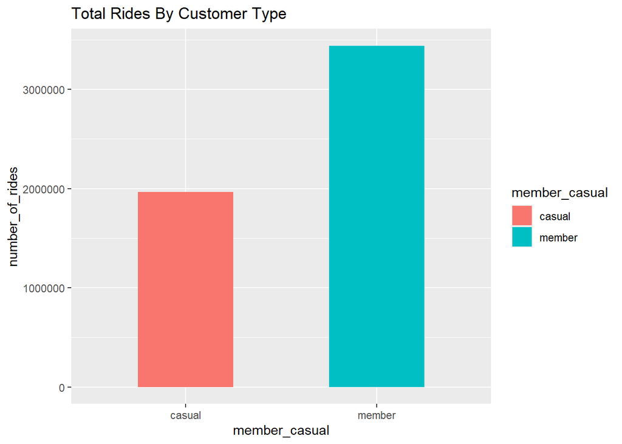

```r
view(cyclistic_date)
cyclistic_date %>%
  group_by(member_casual)%>%
  summarize(number_of_rides = n())%>%
  arrange(member_casual)%>%
  ggplot(aes(x = member_casual, y = number_of_rides, fill = member_casual)) +
  labs(title = "Total Rides By Customer Type") +
  geom_col(width = 0.5, position = position_dodge(width = 0.5)) +
  scale_y_continuous(labels = function(x) format(x, scientific = FALSE))
```

### VISUAL 2: AVERAGE RIDE LENGTH BY CUSTOMER TYPE

```
## Defaulting to continuous.
```

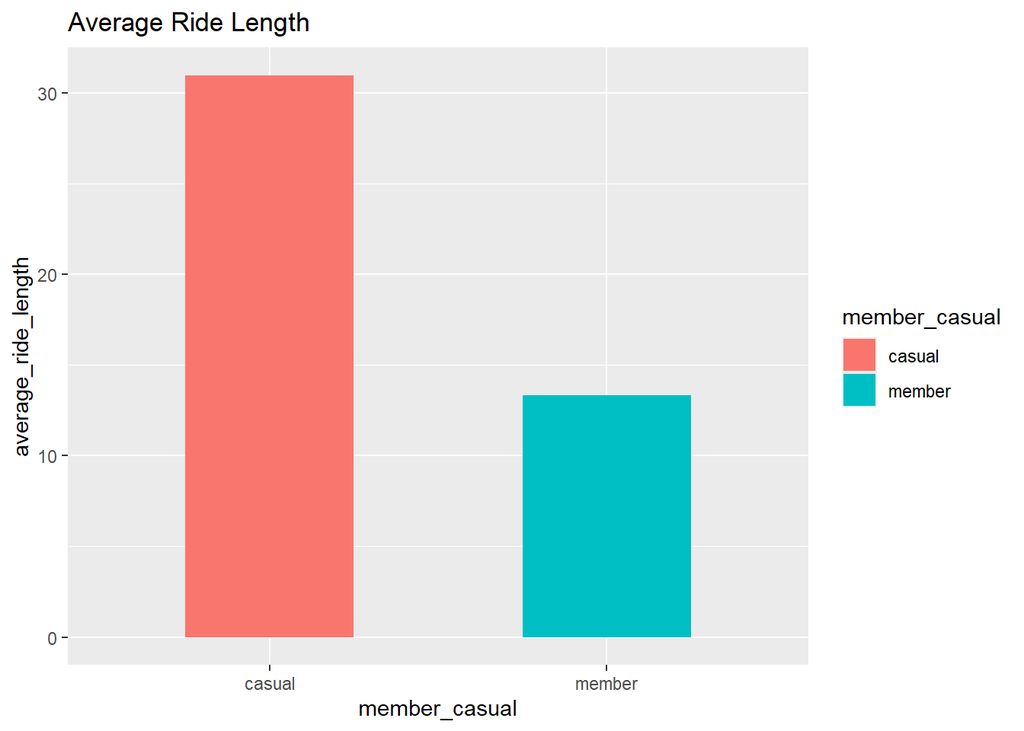

```r
cyclistic_date %>%
  group_by(member_casual)%>%
  summarize(average_ride_length = mean(ride_length))%>%
  ggplot(aes(x = member_casual, y = average_ride_length, fill = member_casual)) +
  labs(title = "Average Ride Length") +
  geom_col(width = 0.5, position = position_dodge(width = 0.5))
```

### VISUAL 3: BUSIEST TIMES BY CUSTOMER TYPE

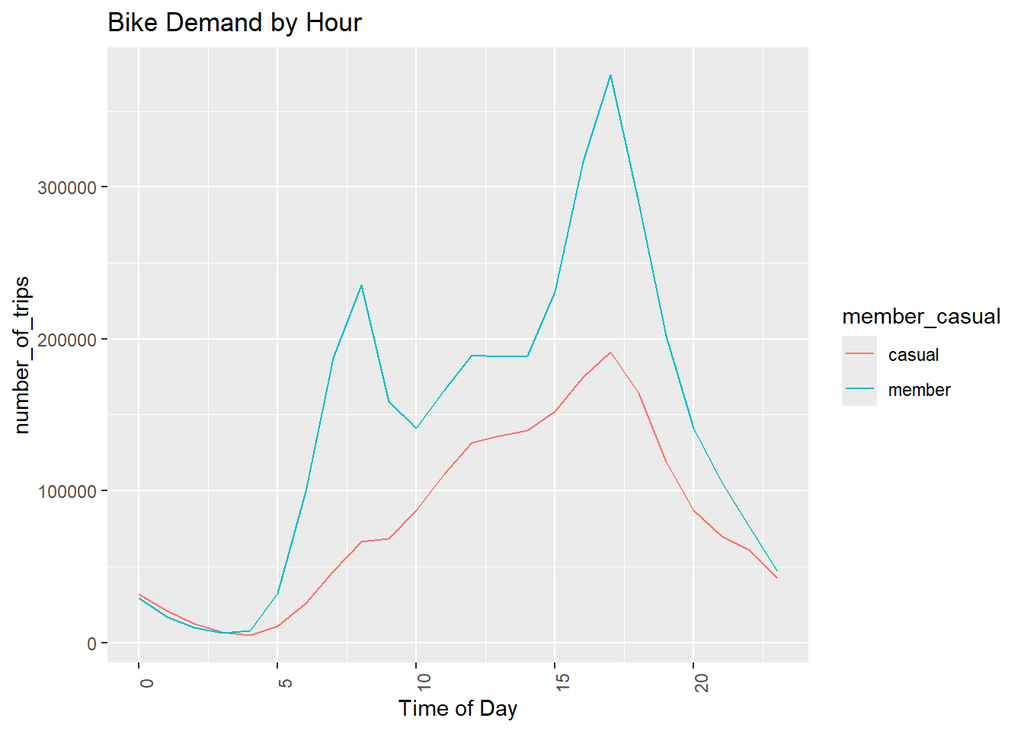

```r
cyclistic_date %>%
  group_by(member_casual, hour)%>%
  summarize(number_of_trips = n())%>%
  ggplot(aes(x = hour, y = number_of_trips, color = member_casual, group = member_casual)) +
  geom_line() +
  labs(title = "Bike Demand by Hour", x = "Time of Day") +
  theme(axis.text.x = element_text(angle = 90)) +
  scale_y_continuous(labels = function(x) format(x, scientific = FALSE))
```

### VISUAL 4: BUSIEST WEEKDAY BY CUSTOMER TYPE

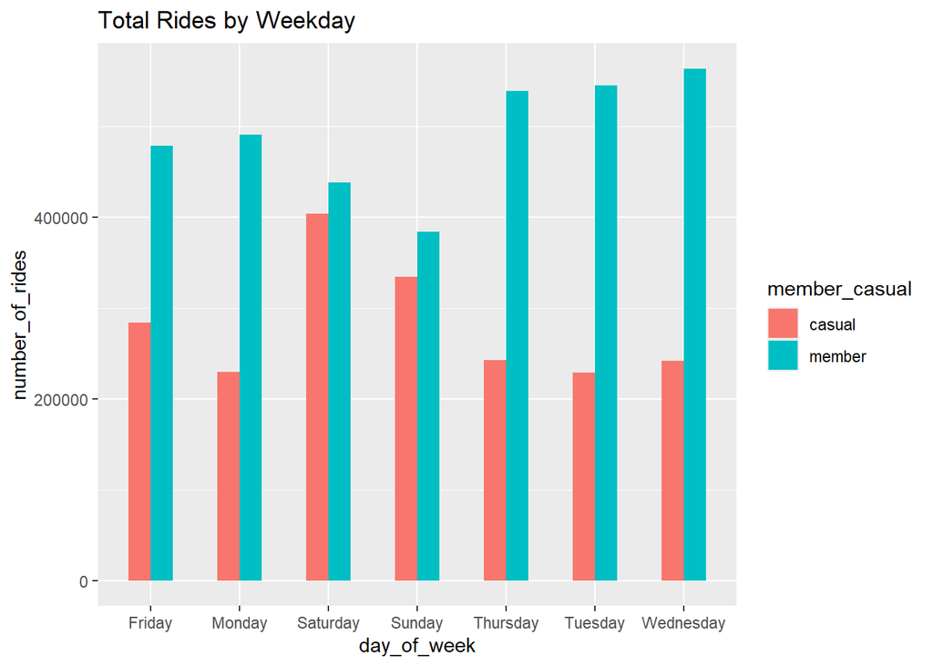

```r
cyclistic_date %>%
  group_by(member_casual, day_of_week)%>%
  summarize(number_of_rides = n())%>%
  arrange(member_casual, day_of_week)%>%
  ggplot(aes(x = day_of_week, y = number_of_rides, fill = member_casual)) +
  labs(title = "Total Rides by Weekday") +
  geom_col(width = 0.5, position = position_dodge(width = 0.5)) +
  scale_y_continuous(labels = function(x) format(x, scientific = FALSE))
```

### VISUAL 5: AVERAGE RIDE LENGTH BY WEEKDAY

```
## Defaulting to continuous.
```

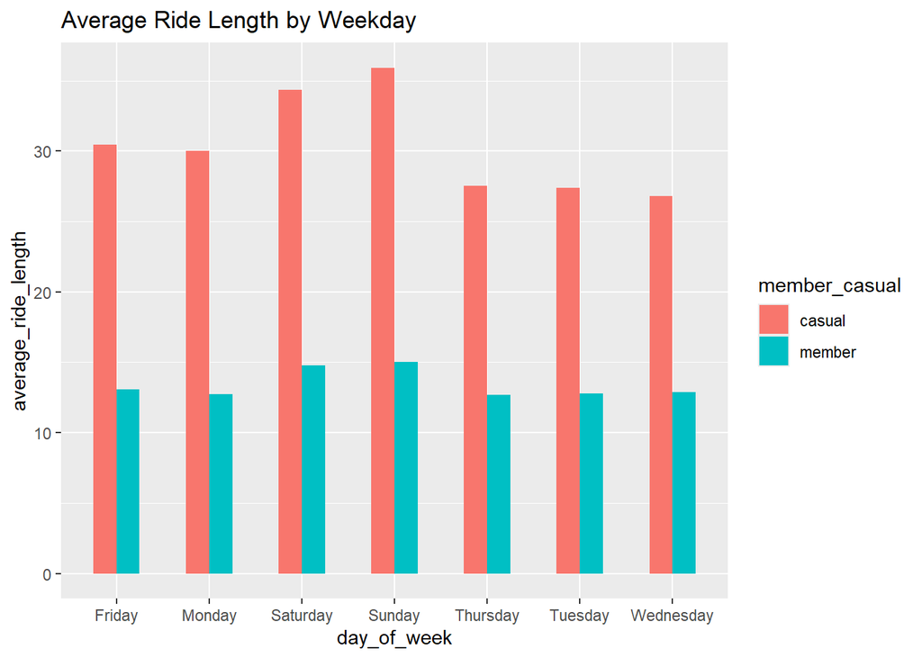

```r
cyclistic_date %>%
  group_by(member_casual, day_of_week)%>%
  summarize(average_ride_length = mean(ride_length))%>%
  ggplot(aes(x = day_of_week, y = average_ride_length, fill = member_casual)) +
  labs(title = "Average Ride Length by Weekday") +
  geom_col(width = 0.5, position = position_dodge(width = 0.5))
```

### VISUAL 6: BUSIEST SEASON BY CUSTOMER TYPE

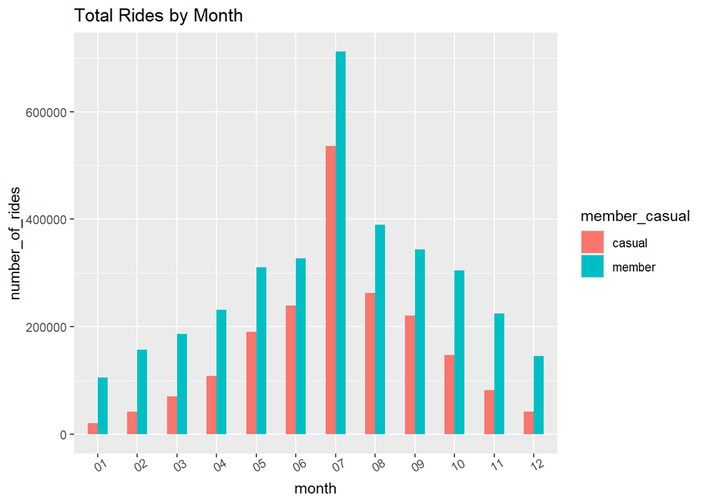

```r
cyclistic_date %>%
  group_by(member_casual, month)%>%
  summarize(number_of_rides = n())%>%
  arrange(member_casual, month)%>%
  ggplot(aes(x = month, y = number_of_rides, fill = member_casual)) +
  labs(title = "Total Rides by Month") +
  theme(axis.text.x = element_text(angle = 30)) +
  geom_col(width = 0.5, position = position_dodge(width = 0.5)) +
  scale_y_continuous(labels = function(x) format(x, scientific = FALSE))
```

### VISUAL 7: MOST POPULAR BIKE BY CUSTOMER TYPE

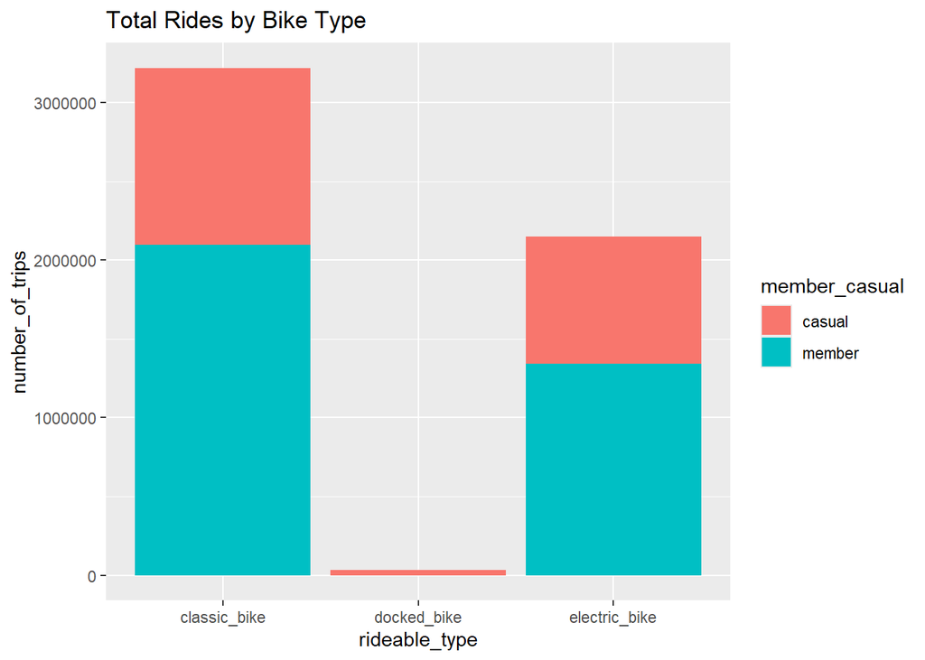

```r
cyclistic_date %>%
  group_by(rideable_type, member_casual)%>%
  summarize(number_of_trips = n())%>%
  ggplot(aes(x = rideable_type, y = number_of_trips, fill = member_casual)) +
  geom_bar(stat = 'identity') +
  labs(title = "Total Rides by Bike Type") +
  scale_y_continuous(labels = function(x) format(x, scientific = FALSE))
```

## KEY FINDINGS:

### Bike Rides and Average Ride Length

-Members took the most bike rides (63.66%) of the total trips, compared to 36.34% of total trips by Casual riders  
-However, Casual riders took longer bike rides (Average Ride Length ~31 minutes) than Members (Average Ride Length ~13 minutes)

### Bike Demand

-The busiest time of the day for both Members and Casual riders peaked in the Afternoon at around 17:00 hr (5 pm)  
-Member riders’ activity also spiked between 07:00 and 08:00 hr  
-The top 3 busiest weekdays for Casual riders were Saturday, Sunday, and Friday  
-The top 3 busiest weekdays for Member riders were Wednesday, Tuesday, and Thursday  
-The busiest season for both customer types was the Summer  
-Casual rides peak in the Summer months and drops dramatically (-57%) in the Fall  
-Member rides remained relatively high through the Fall and in Winter

### Bike Type Popularity

-The most popular bike for both customer types was the Classic Bike  
-Of all rides, 59.59% were done on the Classic Bike  
-The second most popular bike was the Electric Bike (39.77% of all rides)  
-Among Electric Bike users, Member riders (1,342,789; 62.47%) used it more than Casual riders (806,567; 37.53%)  
-There were no Member rides on the Docked Bikes  
-Only Casual riders used the Docked Bikes, which only accounted for 34,286 rides (0.63% of all rides) across the 12 months

# PHASE 6: ACT

### MY TOP THREE RECOMMENDATIONS:

1. **Introduce Seasonal and Weekend Membership Plans**:  
   -**Rationale**: Casual riders peak during weekends (Friday to Sunday) and the Summer months, indicating Casual riders’ preference for flexible and recreational usage.  
   -**Implementation**: Offer a “Weekend Warrior” membership that allows unlimited rides on weekends at a lower cost, and a “Summer Membership” that allows unlimited rides or discounts during peak Summer months. These additional membership options can act as “gateway memberships,” allowing casual riders to experience the benefits of membership without a year-long commitment.
2. **Offer Ride Length Benefits for Members**:  
   -**Rationale**: Casual riders tend to take longer rides (average ~31 minutes) than members (average ~13 minutes). Highlighting the benefits of a membership that includes longer ride times without additional fees can attract casual riders.  
   -**Implementation**: Adjust membership benefits to include longer ride durations (e.g., 45-60 minutes) before additional charges apply, specifically catering to casual riders who enjoy extended rides.
3. **Launch Incentive Programs for Casual to Member Conversion**:  
   -**Rationale**: Providing incentives can create a low-risk opportunity for casual riders to explore membership benefits.  
   -**Implementation**: Introduce a “Try Before You Commit” program that offers a one-month trial membership after their first few rides or a discount on membership after reaching a set number of rides. Use digital channels to promote these offers directly to casual riders, emphasizing the cost-saving benefits of becoming a member.

### OTHER RECOMMENDATIONS TO CONSIDER:

4. **Create and Promote Commuter-Friendly Membership Packages**:  
   -**Rationale**: Member riders show a pattern of using bikes for commuting, peaking during weekday mornings and afternoons. Positioning bikes as a commuting solution can attract casual riders who may consider membership for convenience.  
   -**Implementation**: Develop and promote a “Commuter Membership” with perks that include bike availability during rush hours, quick access to bike stations, and/or longer rental time. Digital campaigns targeting city commuters can highlight the time and cost of savings using Cyclistic for daily commutes.
5. **Boost the Popularity of Electric Bikes with Targeted Campaigns**:  
   -**Rationale**: Electric Bikes are used less frequently despite offering an easier and faster riding experience. Increasing their usage can attract casual riders who might find Classic Bikes too physically demanding.  
   -**Implementation**: Offer Electric Bike-focused promotions such as “Electric Bike Experience Days” where casual riders can try them at a discounted rate. Additionally, create exclusive membership tiers featuring enhanced Electric Bike access, making it a compelling reason for casual riders to upgrade to membership.